# **Board Games Analysis**

### Fall 2025 Data Science Project

**Contributors:** Jack Campbell, Aditi Sethi, Melanie Chen, Shree Dave, Nithya Sunkara

## Contributions:

Jack Campbell:

- I worked on the second half of primary analysis. I worked on training/testing a model that predicted the score of a game for future years in a given price range. This was 12 ranges each tested on 4 models with the best model selected for each. After training I then graphed the predicted output of each model price range. Also created Ratings vs Various Parameters for Board Games.

Aditi Sethi:

- I worked on the first half of the primary analysis, specifically focusing on the process of regression that uses different features in the dataset to predict the amazon price of board games.

Melanie Chen:

- I wrote the introduction that introduced our topic of exploration, research questions, and why the topic matters. I also did the dataset curation and detailed the exploratory data analysis sections.

Shree Dave

- I worked on the complex visualizations, which involved graphing correlations and explaining the results and insights of your primary analysis with at least one plot.

Nithya Sunkara

- I worked on the insights and conclusions section, which entailed interpreting our analysis of the board game data set and compiling the overall insights for readers of varying prior knowledge.

# Introduction

For this project, our group decided on the topic of **board games**. Although we are all generally familar with board games through personal experience, we realized that we know very little about the **data-driven** factors that influence popularity, game ratings, and long-term success of each board game. Essentially, we wanted to learn more about their popularity and how they compare to one another. In addition, we wanted to explore what specific factors drive engagement with board games.

In this day and age, children tend to gravitate more towards TV and video games. In general, traditional tabletop games have been facing growing competition from television, mobile apps, and video games. According to a [National Library of Medicine publication](https://pmc.ncbi.nlm.nih.gov/articles/PMC10042352/#:~:text=Introduction,players%27%20and%20nonplayers%27%20abilities.), video games have a global market of 150 billion dollars, while board games have a global market of only 7 billion dollars. Thus, by analyzing a dataset of board games, we hope to uncover what makes board games appealing and how these insights can be used to strengthen the way they're marketed and sold!

Furthermore, from a data-science perspective, this dataset will give us a great opportunity to practice exploratory analysis, visualization-making, feature-interpreting, and a variety of research techniques!

# Data curation

For this project, we chose a [dataset](https://www.kaggle.com/datasets/chik0di/board-games-dataset-complete-features) from the Kaggle website that contains board game information scraped from BoardGameGeek (BGG), the world's largest board game database.

The dataset includes information on game specifications, user ratings, popularity metrics, designer credits, and real-time marketplace pricing for games available on Amazon.

Additionally, this dataset is also a reasonable size, with 2000 rows and 57 columns. This means that there will be plenty of data to dissect and review for this project!

Just like any other Python project, we need to import some libraries. Below are some of the libraries we will be using throughout this project.

One of the main libraries we use throughout this project is [Pandas](https://pandas.pydata.org/). It is a powerful Python library for data manipulation and analysis. It provides easy-to-use tools for working with structured data, such as DataFrames and Series, allowing you to clean, transform, filter, group, and analyze datasets efficiently.

```python
import pandas as pd
import os
import numpy as np
import scipy

# Graph stuff
import plotly.express as px
import matplotlib.pyplot as plt
import plotly.graph_objects as go
import seaborn as sns
import matplotlib.ticker as ticker
import plotly.io as pio


# Regression imports
from sklearn.model_selection import train_test_split
from sklearn.preprocessing import StandardScaler
from sklearn.linear_model import LinearRegression
from sklearn.neighbors import KNeighborsRegressor
from sklearn.tree import DecisionTreeRegressor
from sklearn.ensemble import RandomForestRegressor
from sklearn.model_selection import KFold, cross_val_score

# Make sure all graphs render
pio.renderers.default = "iframe"
pio.renderers.default = "notebook_connected"
```

```python
init_df = pd.read_csv('boardgame-geek-dataset_organized.csv')
```

```python
df = init_df.copy()
```

```python
df.columns
```

```
Index(['row_id', 'boardgame', 'release_year', 'min_players', 'max_players',
       'min_playtime', 'max_playtime', 'minimum_age', 'avg_rating',
       'num_ratings', 'complexity', 'rank_overall', 'owned', 'wishlisted',
       'total_plays', 'fans', 'page_views', 'amazon_price', 'std_deviation',
       'comments', 'monthly_plays', 'previously_owned', 'for_trade',
       'want_trade', 'rating_1', 'rating_2', 'rating_3', 'rating_4',
       'rating_5', 'rating_6', 'rating_7', 'rating_8', 'rating_9', 'rating_10',
       'categories', 'mechanics', 'families', 'designers', 'artists',
       'publishers', 'solo_designers', 'developers', 'graphic_designers',
       'sculptors', 'editors', 'writers', 'insert_designers', 'rank_strategy',
       'rank_thematic', 'rank_family', 'rank_war', 'rank_customizable',
       'rank_abstract', 'rank_party', 'rank_childrens', 'url', 'description'],
      dtype='object')
```

# Exploratory data analysis. (See checkpoint 2.)

Here, we explore the shape and associated information of the dataset.

Like mentioned earlier, there are 2000 entries, with 57 different features (columns)!

```python
print("Shape of the data: ")
display(df.shape)
print(df.info())
```

```
Shape of the data:
```

```
(2000, 57)
```

```
<class 'pandas.core.frame.DataFrame'>
RangeIndex: 2000 entries, 0 to 1999
Data columns (total 57 columns):
 #   Column             Non-Null Count  Dtype
---  ------             --------------  -----
 0   row_id             2000 non-null   int64
 1   boardgame          2000 non-null   object
 2   release_year       2000 non-null   int64
 3   min_players        2000 non-null   int64
 4   max_players        2000 non-null   int64
 5   min_playtime       2000 non-null   int64
 6   max_playtime       2000 non-null   int64
 7   minimum_age        2000 non-null   int64
 8   avg_rating         2000 non-null   float64
 9   num_ratings        2000 non-null   int64
```

[output cut: 50 more lines]

Here, we check for null values within the dataset.

```python
display(df.isnull().sum())
```

|  | 0 |
| --- | --- |
| row_id | 0 |
| boardgame | 0 |
| release_year | 0 |
| min_players | 0 |
| max_players | 0 |
| min_playtime | 0 |
| max_playtime | 0 |
| minimum_age | 0 |
| avg_rating | 0 |
| num_ratings | 0 |
| complexity | 0 |
| rank_overall | 0 |
| owned | 0 |
| wishlisted | 0 |
| total_plays | 0 |
| fans | 0 |
| page_views | 0 |
| amazon_price | 882 |
| std_deviation | 0 |
| comments | 0 |
| monthly_plays | 0 |
| previously_owned | 0 |
| for_trade | 0 |
| want_trade | 0 |
| rating_1 | 0 |
| rating_2 | 0 |
| rating_3 | 0 |
| rating_4 | 0 |
| rating_5 | 0 |
| rating_6 | 0 |
| rating_7 | 0 |
| rating_8 | 0 |
| rating_9 | 0 |
| rating_10 | 0 |
| categories | 5 |
| mechanics | 3 |
| families | 11 |
| designers | 3 |
| artists | 59 |
| publishers | 0 |
| solo_designers | 1837 |
| developers | 1468 |
| graphic_designers | 1357 |
| sculptors | 1882 |
| editors | 1665 |
| writers | 1844 |
| insert_designers | 1901 |
| rank_strategy | 984 |
| rank_thematic | 1607 |
| rank_family | 1386 |
| rank_war | 1870 |
| rank_customizable | 1951 |
| rank_abstract | 1922 |
| rank_party | 1887 |
| rank_childrens | 1983 |
| url | 0 |
| description | 0 |

**dtype:** int64

As you can see above, our data has missing values like NaNs. There are many different ways to handle missing data, such as imputation, interpolation, or model-based filling. But, the method we use throughout this notebook is simply dropping all missing data entries.

In preparation for comparing average ratings to Amazon price in the plot below, we drop all missing values from the features "amazon_price" and "avg_rating".

**Price vs. Rating Scatterplot**

Here, to explore whether a board game's price is related to how well it is rated, we created a scatterplot comparing average user rating to Amazon price.

Each point in the scatterplot represents a board game, with its average rating on the x-axis and its price on the y-axis.

We also add axis labels, a title, and reasonable bounds for the rating (0-10) and price (0-1000) to improve readability.

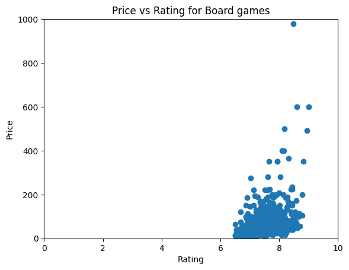

```python
price_df = df[["amazon_price","avg_rating"]].dropna()

plt.scatter(price_df["avg_rating"],price_df["amazon_price"])

# Add labels and title
plt.xlabel('Rating')
plt.ylabel('Price')
plt.title('Price vs Rating for Board games')


plt.xlim(0, 10)
plt.ylim(0, 1000)
# Show plot
plt.show()
```

We then replot the scatterplot without the outlier.

```python
price_df = df[["amazon_price","avg_rating"]].dropna()

Q1 = price_df['amazon_price'].quantile(0.25)
Q3 = price_df['amazon_price'].quantile(0.75)
IQR = Q3 - Q1
lower_bound = Q1 - 1.5 * IQR
upper_bound = Q3 + 1.5 * IQR
no_outliers = price_df[(price_df['amazon_price'] >= lower_bound) & (price_df['amazon_price'] <= upper_bound)]
```

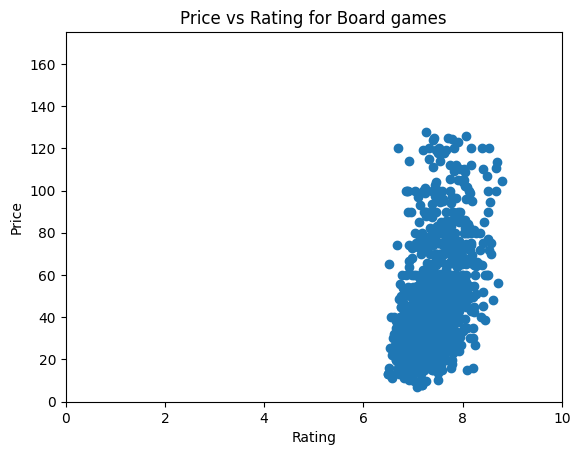

```python
plt.scatter(no_outliers["avg_rating"],no_outliers["amazon_price"])
# Add labels and title
plt.xlabel('Rating')
plt.ylabel('Price')
plt.title('Price vs Rating for Board games')

plt.xlim(0, 10)
plt.ylim(0, 175)
# Show plot
plt.show()
```

**Hypothesis Testing**

In the price vs. rating scatterplot, you can likely to see a trend between the two features. In order to test out this thought, we undergo hypothesis testing.

Hypothesis testing is a statistical method used to make decisions or draw conclusions about a population based on sample data. The null hypothesis is the baseline assumption that there is no relationship between two features. The alternative hypothesis is what we want to investigate, which states that there is a relationship between the two features.

For more information on how hypothesis testing works, visit [this](https://www.geeksforgeeks.org/software-testing/understanding-hypothesis-testing/) website.

*Null Hypothesis:* The price of a games does not have a relationship to the average rating.

*Alternative Hypothesis:* The price of a game has a relationship to the average rating.

*Significance Level:* 0.01

```python
square  = scipy.stats.linregress(no_outliers["amazon_price"], no_outliers["avg_rating"])
print("Correlation",square.rvalue)
print("Pvalue", square.pvalue)
```

```
Correlation 0.4249269406732697
Pvalue 5.06241808100707e-47
```

**Feature Correlation Analysis**

Now that we've established correlation between price and rating, let's observe the relationships between other features in the dataset!

A good way to do this is through feature correlation analysis, and specifically creating a correlation heatmap to easily view relationships.

Darker squares demonstrate strong positive correlations, which mean that as one feature increases, the other also tends to increase.

As you can see below, there is a strong correlation (darker square) between the number of ratings and features related to popularity or engagement.

Overall, this type of visualization can help us to identify key factors that might influence a board game's popularity, rating, or other characteristics.

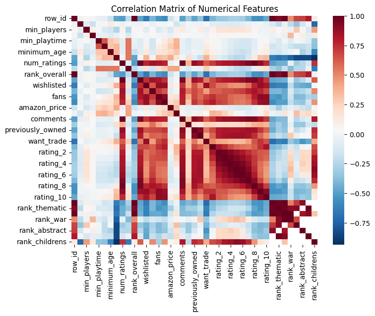

```python
numerical_df = df.select_dtypes(include=np.number)

# correlation matrix
correlation_matrix = numerical_df.corr()

plt.figure(figsize=(8, 6))
sns.heatmap(correlation_matrix, annot=False, cmap='RdBu_r', fmt=".2f")
plt.title('Correlation Matrix of Numerical Features')
plt.show()
```

# Primary analysis

[figure not shown]

```python
columns = ["min_players",	"max_players",	"min_playtime",	"max_playtime",	"num_ratings",	"complexity","total_plays","fans","amazon_price"]
fig, axes = plt.subplots(nrows=3, ncols=3, figsize=(10, 8))
# df["release_year"] =df["release_year"][df["release_year"]>1970]
for col_num in range(len(columns)):
  col = columns[col_num]
  i = col_num // 3
  j = col_num % 3
  df[col] = pd.to_numeric(df[col])
  ax = axes[i, j]
  df_new = df.groupby('avg_rating')[col].mean().reset_index()
  ax.scatter(df_new["avg_rating"], df_new[col])
  ax.set_title(col)
  ax.set_xlabel("Rating")
  ax.set_ylabel(col)

fig.suptitle("Ratings vs Various Parameters for Board Games", fontsize=20)
fig.subplots_adjust(top=0.92, hspace=1.25, wspace=0.5)
plt.tight_layout()
plt.show()
```

# Predicting Amazon Price

Based on the structure of the dataset and the relationships observed in our exploratory plots, we selected regression as our primary modeling technique for predicting Amazon price. The target variable, Amazon price, is a continuous numeric value, making regression a natural fit. Many of the features we examined (complexity, number of ratings, fans, total plays, and playtime) are also numerical and show potential relationships with price. For example, games with higher complexity or higher engagement metrics often appear to be priced higher. To explore this further, we extended our analysis to examine the broader question:

**“Which game attributes most strongly predict a board game's Amazon price?”**

To answer this, we fit several regression models using a diverse set of predictors, compare their performance, and assess which features contribute most to price variation.

We start by selecting numeric features related to complexity, popularity, playtime, and release year, then extract them along with the target variable. All columns are converted to numeric to avoid formatting issues, and any rows with missing values are removed. The resulting cleaned DataFrame (df_price) is ready for use in the regression analysis.

```python
# Features selected to predict price
X_vars = [
    "complexity",
    "avg_rating",
    "num_ratings",
    "total_plays",
    "fans",
    "min_players",
    "max_players",
    "min_playtime",
    "max_playtime",
    "release_year"
]

Y_var = "amazon_price"

df_price = df[X_vars + [Y_var]].copy()

# Convert all columns to numeric safely
for col in df_price.columns:
    df_price[col] = pd.to_numeric(df_price[col], errors="coerce")

# Drop missing values
df_price = df_price.dropna()

df_price.head()
```

|  | complexity | avg_rating | num_ratings | total_plays | fans | min_players | max_players | min_playtime | max_playtime | release_year | amazon_price |
| --- | --- | --- | --- | --- | --- | --- | --- | --- | --- | --- | --- |
| 0 | 3.87 | 8.575 | 53548 | 152594 | 6726 | 2 | 4 | 60 | 120 | 2018 | 69.95 |
| 1 | 2.83 | 8.512 | 56071 | 301410 | 4221 | 2 | 4 | 60 | 60 | 2015 | 76.97 |
| 2 | 3.79 | 8.539 | 54528 | 528979 | 7465 | 1 | 4 | 90 | 150 | 2021 | 71.81 |
| 4 | 4.34 | 8.572 | 26686 | 49484 | 3546 | 3 | 6 | 240 | 480 | 2017 | 172.29 |
| 5 | 3.07 | 8.418 | 53995 | 210763 | 6400 | 1 | 4 | 60 | 120 | 2020 | 51.98 |

First, the feature matrix (X) and target variable (y) are defined. We then divide the data so that 80% is used to train the regression model and 20% is reserved for testing its performance. Because the predictors vary widely in scale, a StandardScaler is applied to normalize them, ensuring that no single feature heavily influences the model. The result is a set of scaled training and testing inputs ready for regression.

```python
X = df_price[X_vars]
y = df_price[Y_var]
X_train, X_test, y_train, y_test = train_test_split(
    X, y, test_size=0.2, random_state=42
)
# Scale numeric data
scaler = StandardScaler()
X_train_scaled = scaler.fit_transform(X_train)
X_test_scaled = scaler.transform(X_test)
```

Four different algorithms are initialized: Linear Regression, K-Nearest Neighbors, a Decision Tree, and a Random Forest.

```python
models = {
    "Linear Regression": LinearRegression(),
    "KNN Regressor": KNeighborsRegressor(n_neighbors=5),
    "Decision Tree": DecisionTreeRegressor(random_state=42),
    "Random Forest": RandomForestRegressor(random_state=42)
}
```

We use KFold to randomly divide the training data into five parts. For each model, cross_val_score computes the R² score across all folds, and the average and standard deviation are printed to help identify which algorithm generalizes best.

```python
kf = KFold(n_splits=5, shuffle=True, random_state=42)

for name, model in models.items():
    scores = cross_val_score(
        model,
        X_train_scaled,
        y_train,
        scoring="r2",
        cv=kf
    )
    print(f"{name}: Mean R² = {scores.mean():.4f} (+/- {scores.std():.4f})")
```

```
Linear Regression: Mean R² = 0.1790 (+/- 0.0715)
KNN Regressor: Mean R² = 0.1254 (+/- 0.1269)
Decision Tree: Mean R² = -0.5571 (+/- 0.5260)
Random Forest: Mean R² = 0.0534 (+/- 0.1980)
```

The cross-validation results indicate that predicting a board game's Amazon price is challenging using the selected features. Among the models tested, Linear Regression performed best, explaining only about 18% of the variation in price, while KNN and Random Forest showed weaker and less consistent performance. The Decision Tree performed very poorly, with a negative R², indicating it overfits the training data and fails to generalize. Overall, these results suggest that features like complexity, number of ratings, fans, and total plays capture only a small portion of what influences a game's market price, and other factors may be necessary to better predict price.

Linear Regression had the highest mean R² among the models tested, so we train a Linear Regression model on the scaled training data to predict Amazon price. After fitting the model, it generates predictions for the test set, which can be used to evaluate how well the model estimates game prices. The magnitude of the model’s coefficients also provides insight into which features have the strongest influence on price.

```python
best_model = LinearRegression()
best_model.fit(X_train_scaled, y_train)

y_pred = best_model.predict(X_test_scaled)
```

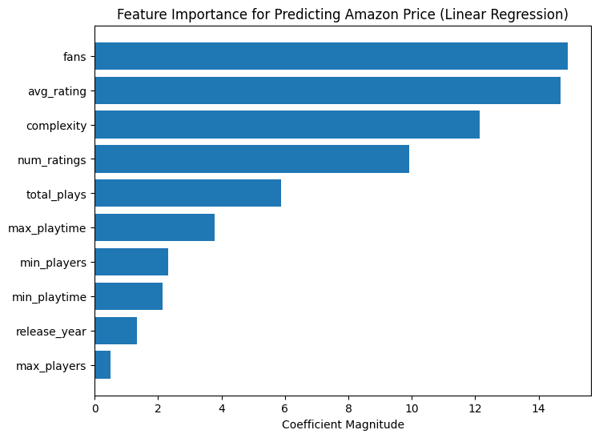

```python
importance = np.abs(best_model.coef_)
indices = np.argsort(importance)

plt.figure(figsize=(8,6))
plt.barh(np.array(X_vars)[indices], importance[indices])
plt.title("Feature Importance for Predicting Amazon Price (Linear Regression)")
plt.xlabel("Coefficient Magnitude")
plt.show()
```

# Predicting the Rating of and Price Range in Future Years

For second part of our primary analysis, we took various price ranges in increments of ten dollars and then trained a model using the increase in ratings over time to predict the rating in future years for the given price range.

```python
df_y = df.copy()

vars = ["release_year","avg_rating","amazon_price"] # All the vars we are using in our analysis
df_y["release_year"] = df_y["release_year"][df_y["release_year"]>1950] # Get years after 1950
df_y['release_year'] = df_y['release_year'] - 1950 # Make data smaller and easier to work with
df_y = df_y[vars].dropna()

# Setup X and Y vars for analysis
X_vars = ["release_year"]
Y_vars = ['avg_rating']
```

```python
class BestModel:
  def __init__(self, data, graph, a):
    self.a = a # The number for the range
    # Variables
    self.X = data[X_vars]
    self.Y = data[Y_vars]

    # Graph stuff
    self.ax = graph
    self.ax.scatter(self.X+1950,self.Y)
    self.ax.set_xlabel("release_year")
    self.ax.set_ylabel("avg_rating")

    # Scale the X and Y Variables
    self.scaler_x = StandardScaler()
    self.X_scaled = self.scaler_x.fit_transform(self.X)

    self.scaler_y = StandardScaler()
    self.Y_scaled = self.scaler_y.fit_transform(self.Y).squeeze()

    # The models to use
    self.models = { "KNN": KNeighborsRegressor(),
            "DecisionTree": DecisionTreeRegressor(random_state = seed),
            "LinearRegression": LinearRegression(),
            "RandomForest": RandomForestRegressor(random_state = seed)
    }
  def find_best_model(self):
    # Perform k-fold Cross-Validation for each model
    k_folds = 5
    kf = KFold(n_splits=k_folds, shuffle=True, random_state=seed)

    max_score = -np.inf
    max_model = ""

    for model_name, model in self.models.items():

        # Test to find the best
        cv_scores = cross_val_score(
            model,
            self.X_scaled,
            self.Y_scaled.squeeze(),
            cv=kf,
            scoring='r2'
        )
        # Check what the highest scoring model is and return it
        score = cv_scores.mean()
        if score  > max_score:
          max_score = score
          max_model = model_name

    self.models[max_model].fit(self.X_scaled, self.Y_scaled) # X Scaled

    # Find the linear regression line if its the best model
    if max_model=="LinearRegression":
      self.graph_linear_regresion(model=self.models[max_model])

    # Setup the grapj
    self.ax.set_title(f"\\${self.a*10}-\\${(self.a+1)*10} using {max_model}")
    self.ax.set_xlabel("Year")
    self.ax.set_ylabel("Rating")

    # Return all of the objects
    return ({"model":self.models[max_model],"num":self.a,"scaler_x":self.scaler_x, "scaler_y":self.scaler_y})

  def graph_linear_regresion(self,model):
    # ----- Pick ONE feature to plot (e.g., the first column) -----
    x_feature_train = self.X.iloc[:, 0]          # unscaled feature
    x_feature_scaled = self.X_scaled[:, 0]       # scaled version

    # Predict on the scaled feature
    y_pred_scaled = model.predict(x_feature_scaled.reshape(-1, 1))
    y_pred = self.scaler_y.inverse_transform(y_pred_scaled.reshape(-1,1))

    # Sort by the feature value for a smooth line
    sorted_idx = x_feature_train.argsort()

    # Plot regression line
    self.ax.plot(
        x_feature_train.iloc[sorted_idx]+1950,
        y_pred[sorted_idx],
        linewidth=4,
        label="Regression Line",
        color="green"
    )
```

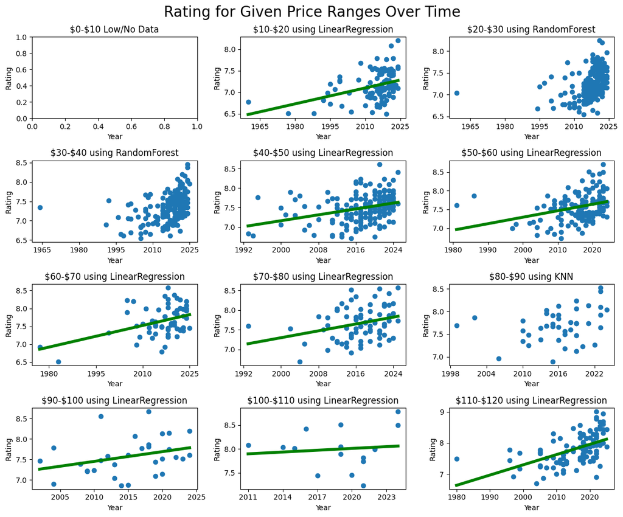

```python
predictors = []
fig, axes = plt.subplots(nrows=4, ncols=3, figsize=(12, 10))
fig.suptitle("Rating for Given Price Ranges Over Time", fontsize=20)
fig.subplots_adjust(top=0.92, hspace=1.25, wspace=0.5)

for a in range(0,12):
  start = a*10
  end = (a+1)*10
  if(a*10>=110):
    data = df_y[df_y['amazon_price']>=start].copy()
  else:
    data = df_y[(df_y['amazon_price']>=start) &(df_y['amazon_price']<end)].copy()

  data.drop(columns=['amazon_price'],inplace=True)


  # Graph Stuff
  i = a // 3
  j = a % 3
  ax = axes[i, j]
  ax.set_title(f"\\${start}-\\${end} Low/No Data")
  ax.set_xlabel("Year")
  ax.set_ylabel("Rating")
  ax.xaxis.set_major_locator(ticker.MaxNLocator(integer=True))
  ax.xaxis.set_major_locator(ticker.MaxNLocator(nbins=5))

  # Exit loop if there is not enough data for that range
  if data.empty or len(data)<=10:
    continue
  find_best = BestModel(data,graph=ax,a=a )
  predictors.append(find_best.find_best_model())

plt.tight_layout()
plt.show()
```

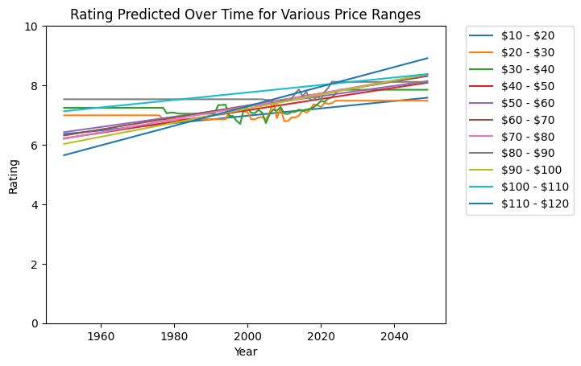

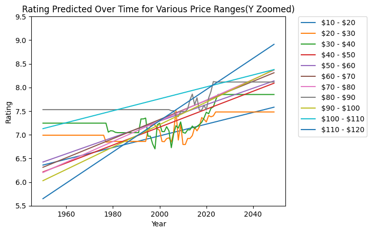

|  | Year | $10 - $20 | $20 - $30 | $30 - $40 | $40 - $50 | $50 - $60 | $60 - $70 | $70 - $80 | $80 - $90 | $90 - $100 | $100 - $110 | $110 - $120 |
| --- | --- | --- | --- | --- | --- | --- | --- | --- | --- | --- | --- | --- |
| 60 | 2010 | 7.100456 | 6.794010 | 7.048931 | 7.350463 | 7.462845 | 7.522934 | 7.513100 | 7.4904 | 7.451668 | 7.885207 | 7.625950 |
| 70 | 2020 | 7.224021 | 7.270334 | 7.475979 | 7.539844 | 7.636048 | 7.724703 | 7.731578 | 7.5248 | 7.688749 | 8.011254 | 7.955437 |
| 80 | 2030 | 7.347587 | 7.481542 | 7.850333 | 7.729226 | 7.809252 | 7.926471 | 7.950055 | 8.1140 | 7.925830 | 8.137302 | 8.284925 |
| 90 | 2040 | 7.471152 | 7.481542 | 7.850333 | 7.918608 | 7.982455 | 8.128239 | 8.168532 | 8.1140 | 8.162911 | 8.263350 | 8.614412 |

```python
df_final= pd.DataFrame({'Year': [a +1950 for a in range(100)]})
fig1, ax1 = plt.subplots()

for info in predictors:
  # Output name
  name = f"${info["num"]*10} - ${(info["num"]+1)*10}"

  # Setup x data for permission
  X_new = pd.DataFrame({'release_year':[a for a in range(100)]})  # 3 samples, 1 feature
  X_new_scaled = info["scaler_x"].transform(X_new)

  # Setup Y data and predict
  predicted_scaled = info["model"].predict(X_new_scaled)
  df_final[name] = info["scaler_y"].inverse_transform(predicted_scaled.reshape(1, -1))[0]

  # Plot the line of the results
  ax1.plot(df_final['Year'], df_final[name], label = name.replace("$","\\$"))

# Setup the overall plot
ax1.legend(bbox_to_anchor=(1.05, 1), loc='upper left', borderaxespad=0.)
ax1.set_xlabel("Year")
ax1.set_ylabel("Rating")
ax1.set_title("Rating Predicted Over Time for Various Price Ranges")
ax1.set_ylim(0,10)

# Make a copy for zoomed in view
fig2, ax2 = plt.subplots()

for line in ax1.get_lines():
    ax2.plot(line.get_xdata(),line.get_ydata(),label= line.get_label())
ax2.legend(bbox_to_anchor=(1.05, 1), loc='upper left', borderaxespad=0.)
ax2.set_xlabel("Year")
ax2.set_ylabel("Rating")
ax2.set_ylim(5.5,9.5)
ax2.set_title("Rating Predicted Over Time for Various Price Ranges(Y Zoomed)")
plt.show()

# Display predictions for specific years
years_to_display = [2010,2020,2030,2040]
display(df_final[df_final['Year'].isin(years_to_display)])
```

# Complex Visualization

Visualization #1: This scatter plot shows the relationship between 'avg_rating' and 'amazon_price'. The size of the markers in the plot represent 'num_ratings', providing insight into how amazon price, player satisfaction, and popularity are interrelated.

```python
fig = px.scatter(
    df,
    x="amazon_price",
    y="avg_rating",
    size="num_ratings",
    title="Average Rating vs. Amazon Price, with Number of Ratings",
    labels={"amazon_price": "Amazon Price","avg_rating": "Average Rating","num_ratings": "Number of Ratings"},
    )
fig.update_xaxes(range=[0, 250])
fig.show()
```

[interactive chart not shown]

Visualization #2: This histogram displays the frequency distribution of average ratings across all board games in the dataset. It helps us understand the general sentiment and how often certain rating scores appear.

```python
fig2 = px.histogram(
    df,
    x="avg_rating",
    nbins=20,
    title="Distribution of Average Board Game Ratings",
    labels={
        "avg_rating": "Average Rating",
        "count": "Number of Games"},
    marginal="box",
    color_discrete_sequence=['purple'])

fig2.update_layout(
    xaxis_title="Average Rating",
    yaxis_title="Number of Games",
    bargap=0.1)

fig2.show()
```

[interactive chart not shown]

Visualization #3: This bar chart shows the average rating of board games for each release year. This helps us observe general trends in ratings over time without additional complexities, providing a simple view of how game quality, as perceived by players, might have changed or remained consistent across different eras.

```python
df_avg_rating_by_year = df.groupby('release_year')['avg_rating'].mean().reset_index()
df_avg_rating_by_year = df_avg_rating_by_year[df_avg_rating_by_year['release_year'] > 1900]

fig3 = px.bar(
    df_avg_rating_by_year,
    x="release_year",
    y="avg_rating",
    title="Average Board Game Rating by Release Year",
    labels={
        "release_year": "Release Year",
        "avg_rating": "Average Rating"},
    color="avg_rating",
    color_continuous_scale=px.colors.sequential.Plasma)

fig3.update_layout(
    xaxis_title="Release Year",
    yaxis_title="Average Rating",
    xaxis_type='category',
    coloraxis_colorbar=dict(
        title="Average Rating",
        thicknessmode="pixels", thickness=20,
        lenmode="pixels", len=200,
        yanchor="middle", y=0.5,
        xanchor="left", x=1.05,
        orientation="v"))

fig3.show()
```

[interactive chart not shown]

# Insights and Conclusions

Now, to tie it all together, let's talk about what we got out of our data analysis. Through our exploration and analysis of this board game dataset, we were able to gain many valuable insights about various board games' popularity, ratings, pricing, and long-term success as a whole.

Based on the hypothesis testing, where the p-value was less than the significance value of 0.01, representing a statistically significant positive relationship between price and rating, we rejected the null hypothesis that there is no correlation between the two metrics. Based on the correlation value we got, which is positive, we can also say that the higher the price of a game, the higher its rating is.

The feature correlation analysis allowed us to use a correlation heatmap to visualize various relationships and their strengths. Based on this correlation heatmap that we generated, it is evident that the number of ratings feature is often strongly correlated to features that represent popularity or engagement for the board game, such as wishlisted, fans, comments, and previously owned. This means that the higher the number of ratings is, the more popular the board games tend to be, considering there are a higher number of things like comments and ownership.

For the primary analysis that we used regression to complete, we were aiming to best predict the Amazon price of a game and distinguish which attributes of a board game most strongly and accurately predict the board game's price on Amazon. The features that we evaluated using various regression models were related to complexity, popularity, playtime, and release data. After cleaning, splitting, and generating the models, the cross-validation results that we got indicated that it was difficult to accurately predict a board game's Amazon price based solely on the features that we selected. However, based on the Linear Regression model and bar chart, we saw that the number of fans and average rating of a board game were the two most important for predicting the Amazon price. This insight tells us that the number of fans a board game has and the average rating of a board game are the most important features in being able to predict the board game's prices. Analyzing this relationship, we can see how the two features relate to each other becuase a higher number of fans will generally mean a higher average rating. Since there are more people who like the game and prices are often based on market demand, the more people who like the game, the higher the rating will be, so it is likely that the price will also be higher since there is a larger number of people who want the game.

In the second part of our primary analysis, we took various price ranges in increments of ten dollars and then used the increase in ratings over time to predict the average rating in future years for the given price range. For this, we tested different regression models and used the best-performing model for the prediction shown in the graphs. Based on these graphs, we are able to identify that over time, ratings tend to increase, which could be due to the board game being on the market for longer.

Overall, our analysis suggests that board game success, defined by higher ratings and more popularity, is driven not so much by mechanical/technical factors such as complexity, playtime, or release date, but rather more so by engagement, as even perceived value. Despite higher-priced games also having high average ratings based on our regression analysis, the number of fans actually proved to be the most important feature in predicting board game prices. Although our primary analysis revealed that it is difficult to predict prices solely based on complexity, popularity, playtime, and release year, it still highlighted that long-term success in the board game market is tied most closely to the engagement of the game. This means that for board game developers, rather than trying to build complex, time-consuming games, they should focus on ideas that will resonate with a wide audience and have a high perceived value, not just for a few years but long-term, maintaining an essentially timeless relevance.